# Описание проекта

Мы работаем в стартапе, который продаёт продукты питания. Нужно разобраться, как ведут себя пользователи нашего мобильного приложения.

# Доступные данные:

В нашем распоряжении имеется лог событий logs_exp:

- EventName — название события;
- DeviceIDHash — уникальный идентификатор пользователя;
- EventTimestamp — время события;
- ExpId — номер эксперимента: 246 и 247 — контрольные группы, а 248 — экспериментальная.

# Цели проекта:

- Выполнить анализ данных,
- Подготовить презентацию исследования для инвесторов.

# Содержание

1. Подготовка данных
2. Изучение данных
3. Изучение воронки событий
4. Изучение результатов эксперимента
5. Общие выводы исследования

# 1. Подготовка данных из файлов

Импортируем библиотеки:

```python
import pandas as pd
from collections import Counter
import numpy as np
from numpy import median
from datetime import datetime
import time
import datetime as dt
import matplotlib.pyplot as plt
from matplotlib import pyplot as plt
from plotly import graph_objects as go
from scipy import stats as st
import scipy.stats as stats
import seaborn as sns
import math as mth
import warnings
warnings.filterwarnings("ignore")
pd.set_option('max_colwidth', -1)
```

Открываем файлы:

```python
try:
    logs_exp = pd.read_csv('logs_exp.csv',sep='\t')
except:
    logs_exp = pd.read_csv('/datasets/logs_exp.csv',sep='\t')
```

Предпросмотр файла:

```python
logs_exp.head()
```

|  | EventName | DeviceIDHash | EventTimestamp | ExpId |
| --- | --- | --- | --- | --- |
| 0 | MainScreenAppear | 4575588528974610257 | 1564029816 | 246 |
| 1 | MainScreenAppear | 7416695313311560658 | 1564053102 | 246 |
| 2 | PaymentScreenSuccessful | 3518123091307005509 | 1564054127 | 248 |
| 3 | CartScreenAppear | 3518123091307005509 | 1564054127 | 248 |
| 4 | PaymentScreenSuccessful | 6217807653094995999 | 1564055322 | 248 |

```python
logs_exp.describe()
```

|  | DeviceIDHash | EventTimestamp | ExpId |
| --- | --- | --- | --- |
| count | 2.441260e+05 | 2.441260e+05 | 244126.000000 |
| mean | 4.627568e+18 | 1.564914e+09 | 247.022296 |
| std | 2.642425e+18 | 1.771343e+05 | 0.824434 |
| min | 6.888747e+15 | 1.564030e+09 | 246.000000 |
| 25% | 2.372212e+18 | 1.564757e+09 | 246.000000 |
| 50% | 4.623192e+18 | 1.564919e+09 | 247.000000 |
| 75% | 6.932517e+18 | 1.565075e+09 | 248.000000 |
| max | 9.222603e+18 | 1.565213e+09 | 248.000000 |

Нестандартных значений, типа минусовых, не видно. Данные в хорошем состоянии.

```python
logs_exp.info()
```

```
<class 'pandas.core.frame.DataFrame'>
RangeIndex: 244126 entries, 0 to 244125
Data columns (total 4 columns):
EventName         244126 non-null object
DeviceIDHash      244126 non-null int64
EventTimestamp    244126 non-null int64
ExpId             244126 non-null int64
dtypes: int64(3), object(1)
memory usage: 7.5+ MB
```

Пропущенных либо неотформатированных позиций нет.

Проверим на дубликаты:

```python
duplicates = logs_exp[logs_exp.duplicated(keep='last')]
duplicates.shape
```

```
(413, 4)
```

Дубликаты есть. Избавимся от них:

```python
logs_exp = logs_exp.drop_duplicates()
logs_exp.shape
```

```
(243713, 4)
```

Для удобства читаемости переименуем столбцы:

```python
logs_exp = logs_exp.rename(columns={"EventName": "event_name",
                         "DeviceIDHash": "id_hash", "EventTimestamp": "time_stamp", "ExpId": "group"})
```

Переведем столбец time_stamp в формат datetime:

```python
logs_exp['time_stamp'] = pd.to_datetime(logs_exp['time_stamp'], unit='s')
logs_exp['date'] = pd.to_datetime(logs_exp['time_stamp']).dt.date
logs_exp.head()
```

|  | event_name | id_hash | time_stamp | group | date |
| --- | --- | --- | --- | --- | --- |
| 0 | MainScreenAppear | 4575588528974610257 | 2019-07-25 04:43:36 | 246 | 2019-07-25 |
| 1 | MainScreenAppear | 7416695313311560658 | 2019-07-25 11:11:42 | 246 | 2019-07-25 |
| 2 | PaymentScreenSuccessful | 3518123091307005509 | 2019-07-25 11:28:47 | 248 | 2019-07-25 |
| 3 | CartScreenAppear | 3518123091307005509 | 2019-07-25 11:28:47 | 248 | 2019-07-25 |
| 4 | PaymentScreenSuccessful | 6217807653094995999 | 2019-07-25 11:48:42 | 248 | 2019-07-25 |

Проверим финальный вариант таблицы:

```python
logs_exp.info()
```

```
<class 'pandas.core.frame.DataFrame'>
Int64Index: 243713 entries, 0 to 244125
Data columns (total 5 columns):
event_name    243713 non-null object
id_hash       243713 non-null int64
time_stamp    243713 non-null datetime64[ns]
group         243713 non-null int64
date          243713 non-null object
dtypes: datetime64[ns](1), int64(2), object(2)
memory usage: 11.2+ MB
```

**На этом подготовка данных завершена**

# 2. Изучение данных

**Задачи:**

- Сколько всего событий в логе?
- Сколько всего пользователей в логе?
- Сколько в среднем событий приходится на пользователя?
- Данными за какой период мы располагаем? Найти максимальную и минимальную дату. Построить гистограмму по дате и времени. Определить и сформировать полные данные.
- Сколько событий и пользователей мы потеряли, отбросив старые данные?
- Проверить, что у нас есть пользователи из всех трёх экспериментальных групп.

```python
logs_exp.head()
```

|  | event_name | id_hash | time_stamp | group | date |
| --- | --- | --- | --- | --- | --- |
| 0 | MainScreenAppear | 4575588528974610257 | 2019-07-25 04:43:36 | 246 | 2019-07-25 |
| 1 | MainScreenAppear | 7416695313311560658 | 2019-07-25 11:11:42 | 246 | 2019-07-25 |
| 2 | PaymentScreenSuccessful | 3518123091307005509 | 2019-07-25 11:28:47 | 248 | 2019-07-25 |
| 3 | CartScreenAppear | 3518123091307005509 | 2019-07-25 11:28:47 | 248 | 2019-07-25 |
| 4 | PaymentScreenSuccessful | 6217807653094995999 | 2019-07-25 11:48:42 | 248 | 2019-07-25 |

### Сколько всего событий в логе?

```python
print("Количество событий в логе:",logs_exp['event_name'].count())
```

```
Количество событий в логе: 243713
```

Мы можем показать их распределение на графике:

[figure not shown]

```python
data = logs_exp.groupby('event_name')['event_name'].count()

plt.figure(figsize=(5, 5))
labels = logs_exp['event_name'].unique()

plt.pie(data,
        labels = labels,
        autopct='%.2f%%',
        startangle=20,
        shadow=True,
       textprops={'fontsize': 12})

plt.title("Соотношение типов пользовательских событий", fontsize='15')

plt.show()
```

`Естественно, это общая картина, без учета групп А/В тестов.`

### Сколько всего пользователей в логе?

```python
print("Количество уникальных пользователей в логе:",logs_exp['id_hash'].nunique())
```

```
Количество уникальных пользователей в логе: 7551
```

### Сколько в среднем событий приходится на пользователя?

```python
user_mean = logs_exp.groupby('id_hash')['event_name'].count().reset_index()
print("Среднее количество событий на пользователя:",user_mean['event_name'].mean())
```

```
Среднее количество событий на пользователя: 32.27559263673685
```

### Данными за какой период вы располагаете?

- Найдем максимальную и минимальную дату:

```python
print("Максимальная дата пользовательской активности:",logs_exp['date'].max())
print("Минимальная дата пользовательской активности:",logs_exp['date'].min())
```

```
Максимальная дата пользовательской активности: 2019-08-07
Минимальная дата пользовательской активности: 2019-07-25
```

Построим гистограмму по дате и времени:

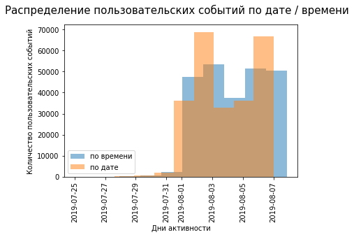

```python
plt.hist(logs_exp['time_stamp'], alpha=0.5, label='по времени')
plt.hist(logs_exp['date'], alpha=0.5, label='по дате')
plt.xlabel('Дни активности')
plt.xticks(rotation=90)
#plt.box(False)
#plt.grid(False)
plt.ylabel('Количество пользовательских событий')
plt.legend(loc='lower left')
plt.suptitle('Распределение пользовательских событий по дате / времени', fontsize='15');
```

- Как мы видим, данные по времени и датам не совпадают. Данные по датам опережают данные по времени, а также вероятен перенос данных из одного периода в другой, т.к. данные по датам более резко разделены, поэтому данные по времени распределены более ровно.
- Также, мы видим, что данные до 01 августа 2019 года практически отсутствуют. Мы можем отбросить значения ранее этой даты:

```python
logs_exp_updated = logs_exp[logs_exp['time_stamp']>='2019-08-01']
```

Посттроим обновленный график:

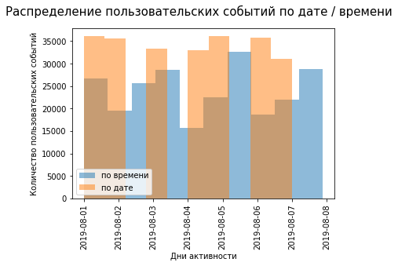

```python
plt.hist(logs_exp_updated['time_stamp'], alpha=0.5, label='по времени')
plt.hist(logs_exp_updated['date'], alpha=0.5, label='по дате')
plt.xlabel('Дни активности')
plt.xticks(rotation=90)
plt.ylabel('Количество пользовательских событий')
plt.legend(loc='lower left')
plt.suptitle('Распределение пользовательских событий по дате / времени', fontsize='15');
```

Теперь данные "очищены".

### Сколько событий и пользователей мы потеряли, отбросив старые данные?

```python
print("Разница по количеству событий:",logs_exp.shape[0]-logs_exp_updated.shape[0])
print("Разница по количеству пользователей:",logs_exp['id_hash'].nunique()-logs_exp_updated['id_hash'].nunique())
```

```
Разница по количеству событий: 2826
Разница по количеству пользователей: 17
```

Мы потеряли около 1% данных по событиям и около 0,2% данных по пользователям. Потери приемлемы.

### Проверим наличие пользователей из всех трёх экспериментальных групп

```python
stat = logs_exp_updated.groupby('group')['id_hash'].count().reset_index()
stat.head()
```

|  | group | id_hash |
| --- | --- | --- |
| 0 | 246 | 79302 |
| 1 | 247 | 77022 |
| 2 | 248 | 84563 |

Мы видим, что имеются данные по всем трем экспериментальным группам и их размеры сопоставимы.

# 3. Изучение воронки событий

**Задачи:**

- Посмотрите, какие события есть в логах, как часто они встречаются. Отсортируйте события по частоте.
- Посчитайте, сколько пользователей совершали каждое из этих событий. Отсортируйте события по числу пользователей. Посчитайте долю пользователей, которые хоть раз совершали событие.
- Предположите, в каком порядке происходят события. Все ли они выстраиваются в последовательную цепочку? Их не нужно учитывать при расчёте воронки.
- По воронке событий посчитайте, какая доля пользователей проходит на следующий шаг воронки (от числа пользователей на предыдущем). То есть для последовательности событий A → B → C посчитайте отношение числа пользователей с событием B к количеству пользователей с событием A, а также отношение числа пользователей с событием C к количеству пользователей с событием B.
- На каком шаге теряете больше всего пользователей?
- Какая доля пользователей доходит от первого события до оплаты?

```python
logs_exp_updated.head()
```

|  | event_name | id_hash | time_stamp | group | date |
| --- | --- | --- | --- | --- | --- |
| 2828 | Tutorial | 3737462046622621720 | 2019-08-01 00:07:28 | 246 | 2019-08-01 |
| 2829 | MainScreenAppear | 3737462046622621720 | 2019-08-01 00:08:00 | 246 | 2019-08-01 |
| 2830 | MainScreenAppear | 3737462046622621720 | 2019-08-01 00:08:55 | 246 | 2019-08-01 |
| 2831 | OffersScreenAppear | 3737462046622621720 | 2019-08-01 00:08:58 | 246 | 2019-08-01 |
| 2832 | MainScreenAppear | 1433840883824088890 | 2019-08-01 00:08:59 | 247 | 2019-08-01 |

### Какие события есть в логах, как часто они встречаются? Сортировка событий по частоте.

Подготовим таблицу и отсортируем данные:

```python
log_stats = logs_exp_updated.groupby(['event_name']).size().reset_index()
log_stats.columns=['event_name','event_count']
log_stats = log_stats.sort_values(by='event_count',ascending=False)
log_stats.head()
```

|  | event_name | event_count |
| --- | --- | --- |
| 1 | MainScreenAppear | 117328 |
| 2 | OffersScreenAppear | 46333 |
| 0 | CartScreenAppear | 42303 |
| 3 | PaymentScreenSuccessful | 33918 |
| 4 | Tutorial | 1005 |

Покажем на графике:

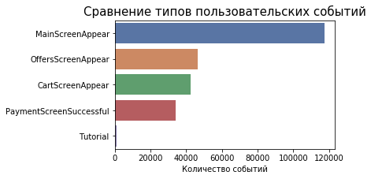

```python
data = log_stats.sort_values(by='event_count',ascending=False)
plt.figure(figsize=(5, 3))
sns.barplot(x='event_count', y='event_name', data=data, palette="deep")
plt.title("Сравнение типов пользовательских событий", fontsize='15')
plt.xlabel('Количество событий')
plt.ylabel('')
plt.show()
```

### Сколько пользователей совершали каждое из этих событий? Сортировка событий по числу пользователей. Подсчет доли пользователей, которые хоть раз совершали событие.

Посчитаем, сколько пользователей совершали каждое из этих событий и отсортируем события по числу пользователей.

```python
log_stats_merged = logs_exp_updated.groupby('event_name')['id_hash'].nunique().sort_values(ascending=False).reset_index()
log_stats_merged.columns=['event_name','unique_id_count']
log_stats_merged.head()
```

|  | event_name | unique_id_count |
| --- | --- | --- |
| 0 | MainScreenAppear | 7419 |
| 1 | OffersScreenAppear | 4593 |
| 2 | CartScreenAppear | 3734 |
| 3 | PaymentScreenSuccessful | 3539 |
| 4 | Tutorial | 840 |

Добавим столбец с подсчетом доли уникальных пользователей в событии от общего числа:

```python
total_unique_ids = logs_exp_updated['id_hash'].nunique()
log_stats_merged['% of total'] = round((log_stats_merged['unique_id_count'] / total_unique_ids)*100,2)
log_stats_merged.head()
```

|  | event_name | unique_id_count | % of total |
| --- | --- | --- | --- |
| 0 | MainScreenAppear | 7419 | 98.47 |
| 1 | OffersScreenAppear | 4593 | 60.96 |
| 2 | CartScreenAppear | 3734 | 49.56 |
| 3 | PaymentScreenSuccessful | 3539 | 46.97 |
| 4 | Tutorial | 840 | 11.15 |

### В каком порядке происходят события, все ли они выстраиваются в последовательную цепочку?

В каком порядке происходят события? Нам видится, что порядок такой же, как отображен в таблице log_stats_merged, и последовательное уменьшение количества пользователей подтверждает это:

```python
log_stats_merged.head()
```

|  | event_name | unique_id_count | % of total |
| --- | --- | --- | --- |
| 0 | MainScreenAppear | 7419 | 98.47 |
| 1 | OffersScreenAppear | 4593 | 60.96 |
| 2 | CartScreenAppear | 3734 | 49.56 |
| 3 | PaymentScreenSuccessful | 3539 | 46.97 |
| 4 | Tutorial | 840 | 11.15 |

- Сначала пользователь загружает главную страницу приложения;
- Затем видит экран с предложениями;
- Далее выбирает товары и попадает в корзину;
- Производит отплату и видит экран успешной оплаты.

Посещение раздела Tutorial не вписывается в эту последовательность, оно может происходить на любом этапе, но также не видно влияния на успешность следующего шага, хотя такое определенно может иметь место. Поэтому для построения воронки Tutorial опустим.

```python
log_stats_funnel = log_stats_merged.loc[0:3][['event_name','unique_id_count']]
log_stats_funnel.head()
```

|  | event_name | unique_id_count |
| --- | --- | --- |
| 0 | MainScreenAppear | 7419 |
| 1 | OffersScreenAppear | 4593 |
| 2 | CartScreenAppear | 3734 |
| 3 | PaymentScreenSuccessful | 3539 |

### Какая доля пользователей проходит на следующий шаг воронки (от числа пользователей на предыдущем)?

По воронке событий посчитаем, какая доля пользователей проходит на следующий шаг воронки (от числа пользователей на предыдущем). То есть для последовательности событий A → B → C посчитаем отношение числа пользователей с событием B к количеству пользователей с событием A, а также отношение числа пользователей с событием C к количеству пользователей с событием B.

Воронку пользовательской активности построим при помощи plotly graph_objects:

```python
fig = go.Figure(go.Funnel(
    y = log_stats_funnel['event_name'],
    x = log_stats_funnel['unique_id_count'],
    textposition = "inside",
    textinfo = "value+percent previous",
    opacity = 0.85, marker = {"color": ["deepskyblue", "lightsalmon", "tan", "teal"]}
        ))
fig.update_layout(
    title_text='Воронка пользовательской активности', title_x=0.5,
    autosize=False,
    width=800,
    height=400,)

fig.show()
```

[interactive chart not shown]

### На каком шаге мы теряем больше всего пользователей?

`Согласно данным, больше всего пользователей мы теряем непосредственно при переходе с первого шага на второй.`

### Какая доля пользователей доходит от первого события до оплаты?

Доля дошедших с момента первого события до оплаты составляет 47,7%.

# 4. Изучение результатов эксперимента

### Сколько пользователей в каждой экспериментальной группе?

```python
logs_exp_updated.head()
```

|  | event_name | id_hash | time_stamp | group | date |
| --- | --- | --- | --- | --- | --- |
| 2828 | Tutorial | 3737462046622621720 | 2019-08-01 00:07:28 | 246 | 2019-08-01 |
| 2829 | MainScreenAppear | 3737462046622621720 | 2019-08-01 00:08:00 | 246 | 2019-08-01 |
| 2830 | MainScreenAppear | 3737462046622621720 | 2019-08-01 00:08:55 | 246 | 2019-08-01 |
| 2831 | OffersScreenAppear | 3737462046622621720 | 2019-08-01 00:08:58 | 246 | 2019-08-01 |
| 2832 | MainScreenAppear | 1433840883824088890 | 2019-08-01 00:08:59 | 247 | 2019-08-01 |

Составим таблицу, отражающую количество пользователей в группах:

```python
group_stats = logs_exp_updated.groupby('group')['id_hash'].nunique().reset_index()
group_stats.columns=['group','group_user_count']
group_stats = group_stats[group_stats['group']<248]
group_stats.head()
```

|  | group | group_user_count |
| --- | --- | --- |
| 0 | 246 | 2484 |
| 1 | 247 | 2513 |

### Находят ли статистические критерии разницу между выборками 246 и 247

**Выберем самое популярное событие**

Согласно воронке log_stats_funnel, самое популярное событие - отображение главного экрана MainScreenAppear.

Посчитаем долю пользователей, совершивших это событие, в двух отдельных группах:

```python
pop_event_share = logs_exp_updated[
    (logs_exp_updated['event_name'] == 'MainScreenAppear')&(logs_exp_updated['group']<248)
    ].groupby('group')['id_hash'].nunique().reset_index()
pop_event_share.columns=['group','unique_id_count']

pop_event_share.head()
```

|  | group | unique_id_count |
| --- | --- | --- |
| 0 | 246 | 2450 |
| 1 | 247 | 2476 |

Объединим с таблицей group_stats и получим долю пользователей, успешно участвоваших в событии:

```python
group_sum_table = group_stats.merge(pop_event_share, how='left', on='group')
group_sum_table['% of total'] = round((group_sum_table['unique_id_count'] / group_sum_table['group_user_count'])*100,2)
group_sum_table.head()
```

|  | group | group_user_count | unique_id_count | % of total |
| --- | --- | --- | --- | --- |
| 0 | 246 | 2484 | 2450 | 98.63 |
| 1 | 247 | 2513 | 2476 | 98.53 |

**Проверим, будет ли отличие между группами статистически достоверным**

Для этого применим гипотезу о равенстве долей.

Сформулируем нулевую и альтернативную гипотезы:

- H0: статистическая разница между выборками 246 и 247 отсутствует
- H1: статистическая разница между выборками 246 и 247 присутствует

Напишем соответствующую функцию:

```python
def stat_check_draft(event):

    alpha = 0.05

    successes = group_sum_table['unique_id_count']
    trials = group_sum_table['group_user_count']

    # пропорция успехов в первой группе:
    p1 = successes[0]/trials[0]

    # пропорция успехов во второй группе:
    p2 = successes[1]/trials[1]

    # пропорция успехов в комбинированном датасете:
    p_combined = (successes[0] + successes[1]) / (trials[0] + trials[1])

    # разница пропорций в датасетах
    difference = p1 - p2

    # считаем статистику в ст.отклонениях стандартного нормального распределения
    z_value = difference / mth.sqrt(
        p_combined * (1 - p_combined) * (1 / trials[0] + 1 / trials[1])
    )

    # задаем стандартное нормальное распределение (среднее 0, ст.отклонение 1)
    distr = st.norm(0, 1)

    p_value = (1 - distr.cdf(abs(z_value))) * 2
    print(f'p-значение {event}: ', p_value)

    if p_value < alpha:
        print(f'Отвергаем нулевую гипотезу для {event}: между долями есть значимая разница')
    else:
        print(f'Не получилось отвергнуть нулевую гипотезу для {event}, нет оснований считать доли разными')

events = log_stats_funnel['event_name'].unique()

print(('Результаты тестирования групп 247 и 246').upper())
print('''
Нулевая и альтернативные гипотезы:
H0: статистическая разница между выборками отсутствует
H1: статистическая разница между выборками присутствует
''')

stat_check_draft(event="MainScreenAppear")
```

```
РЕЗУЛЬТАТЫ ТЕСТИРОВАНИЯ ГРУПП 247 И 246

Нулевая и альтернативные гипотезы:
H0: статистическая разница между выборками отсутствует
H1: статистическая разница между выборками присутствует

p-значение MainScreenAppear:  0.7570597232046099
Не получилось отвергнуть нулевую гипотезу для MainScreenAppear, нет оснований считать доли разными
```

### Можно ли сказать, что разбиение на группы работает корректно?

- На основании выполненных тестов мы можем утверждать о совпадении условий и данных в группах А/А теста, и, соответственно, корректном разбиении групп

Создадим общую таблицу с данными по всем группам:

```python
groups_users_count = logs_exp_updated.groupby('group')['id_hash'].nunique().reset_index()
groups_users_count.columns=['group','group_id_count']
groups_users_count = groups_users_count.append({'group' : 'comb',
                    'group_id_count' : groups_users_count['group_id_count'][0]+groups_users_count['group_id_count'][1]},
                    ignore_index=True)

groups_users_count.head()
```

|  | group | group_id_count |
| --- | --- | --- |
| 0 | 246 | 2484 |
| 1 | 247 | 2513 |
| 2 | 248 | 2537 |
| 3 | comb | 4997 |

```python
groups_funnel = logs_exp_updated.groupby(['event_name','group']).agg({'id_hash': ['nunique']}).reset_index()
groups_funnel.columns=['event_name','group', 'unique_id_count']
groups_funnel = groups_funnel[groups_funnel['event_name'] != 'Tutorial']
groups_funnel = groups_funnel.append({'event_name' : 'CartScreenAppear', 'group' : 'comb',
                    'unique_id_count' : groups_funnel['unique_id_count'][0]+groups_funnel['unique_id_count'][1]},
                    ignore_index=True)
groups_funnel = groups_funnel.append({'event_name' : 'MainScreenAppear', 'group' : 'comb',
                    'unique_id_count' : groups_funnel['unique_id_count'][3]+groups_funnel['unique_id_count'][4]},
                    ignore_index=True)
groups_funnel = groups_funnel.append({'event_name' : 'OffersScreenAppear', 'group' : 'comb',
                    'unique_id_count' : groups_funnel['unique_id_count'][6]+groups_funnel['unique_id_count'][7]},
                    ignore_index=True)
groups_funnel = groups_funnel.append({'event_name' : 'PaymentScreenSuccessful', 'group' : 'comb',
                    'unique_id_count' : groups_funnel['unique_id_count'][9]+groups_funnel['unique_id_count'][10]},
                    ignore_index=True)

groups_funnel = groups_funnel.sort_values(['group', 'unique_id_count'], ascending=[True, False])

groups_funnel.head()
```

|  | event_name | group | unique_id_count |
| --- | --- | --- | --- |
| 3 | MainScreenAppear | 246 | 2450 |
| 6 | OffersScreenAppear | 246 | 1542 |
| 0 | CartScreenAppear | 246 | 1266 |
| 9 | PaymentScreenSuccessful | 246 | 1200 |
| 4 | MainScreenAppear | 247 | 2476 |

```python
groups_funnel = pd.merge(groups_funnel,
                     groups_users_count,
                     on ='group',
                     how ='left')
groups_funnel.head()
```

|  | event_name | group | unique_id_count | group_id_count |
| --- | --- | --- | --- | --- |
| 0 | MainScreenAppear | 246 | 2450 | 2484 |
| 1 | OffersScreenAppear | 246 | 1542 | 2484 |
| 2 | CartScreenAppear | 246 | 1266 | 2484 |
| 3 | PaymentScreenSuccessful | 246 | 1200 | 2484 |
| 4 | MainScreenAppear | 247 | 2476 | 2513 |

```python
groups_funnel['% of group_total'] = round((groups_funnel['unique_id_count'] / groups_funnel['group_id_count'])*100,2)
groups_funnel.head()
```

|  | event_name | group | unique_id_count | group_id_count | % of group_total |
| --- | --- | --- | --- | --- | --- |
| 0 | MainScreenAppear | 246 | 2450 | 2484 | 98.63 |
| 1 | OffersScreenAppear | 246 | 1542 | 2484 | 62.08 |
| 2 | CartScreenAppear | 246 | 1266 | 2484 | 50.97 |
| 3 | PaymentScreenSuccessful | 246 | 1200 | 2484 | 48.31 |
| 4 | MainScreenAppear | 247 | 2476 | 2513 | 98.53 |

Теперь у нас готова таблица с данными для сравнения по группам.

На основании этих данных построим парную воронку групп 246 и 247, чтобы определить, в какой группе идут "потери":

```python
fig = go.Figure()

fig.add_trace(go.Funnel(
    name = 'группа 246',
    orientation = "h",
    y = groups_funnel[groups_funnel['group']==246]['event_name'],
    x = groups_funnel[groups_funnel['group']==246]['unique_id_count'],
    textposition = "inside",
    textinfo = "value+percent previous"))

fig.add_trace(go.Funnel(
    name = 'группа 247',
    orientation = "h",
    y = groups_funnel[groups_funnel['group']==247]['event_name'],
    x = groups_funnel[groups_funnel['group']==247]['unique_id_count'],
    textposition = "inside",
    textinfo = "value+percent previous"))

fig.update_layout(
    title_text='Воронка пользовательской активности групп 246 и 247', title_x=0.5,
    autosize=True)

fig.show()
```

[interactive chart not shown]

Как видим, в группе 247 на втором этапе значения начинают отставать, хотя статистически группы равны, значит, должны быть какие-то технические различия в отображении страниц.

### Выполним проверку с группой с измененным шрифтом.

**Построим воронку пользовательской активности 248 группы относительно группы 246:**

```python
fig = go.Figure()

fig.add_trace(go.Funnel(
    name = 'группа 246',
    orientation = "h",
    y = groups_funnel[groups_funnel['group']==246]['event_name'],
    x = groups_funnel[groups_funnel['group']==246]['unique_id_count'],
    textposition = "inside",
    textinfo = "value+percent previous"))

fig.add_trace(go.Funnel(
    name = 'группа 248',
    orientation = "h",
    y = groups_funnel[groups_funnel['group']==248]['event_name'],
    x = groups_funnel[groups_funnel['group']==248]['unique_id_count'],
    textposition = "inside",
    textinfo = "value+percent previous"))

fig.update_layout(
    title_text='Воронка пользовательской активности групп 246 и 248', title_x=0.5,
    autosize=True)

fig.show()
```

[interactive chart not shown]

Как мы видим, группа 246 опережает группу 248 (с измененными шрифтами) по нескольким показателям, за исключением последнего. Теперь проверим по уровню статистической значимости:

```python
groups_funnel.head()
```

|  | event_name | group | unique_id_count | group_id_count | % of group_total |
| --- | --- | --- | --- | --- | --- |
| 0 | MainScreenAppear | 246 | 2450 | 2484 | 98.63 |
| 1 | OffersScreenAppear | 246 | 1542 | 2484 | 62.08 |
| 2 | CartScreenAppear | 246 | 1266 | 2484 | 50.97 |
| 3 | PaymentScreenSuccessful | 246 | 1200 | 2484 | 48.31 |
| 4 | MainScreenAppear | 247 | 2476 | 2513 | 98.53 |

```python
event=''
def stat_check(event, G1, G2):
    alpha = 0.05
    bonferroni_alpha = alpha / 3
    events = groups_funnel['event_name'].unique()
    print((f'Результаты тестирования групп {G1} и {G2}').upper())
    print('''
    Нулевая и альтернативные гипотезы:
    H0: статистическая разница между выборками отсутствует
    H1: статистическая разница между выборками присутствует
    ''')

    for event in events:
        success_p1 = float(
            groups_funnel['unique_id_count'][(groups_funnel['event_name']==event) & (groups_funnel['group']==G1)])
        trials_p1 = float(
            groups_funnel['group_id_count'][(groups_funnel['event_name']==event) & (groups_funnel['group']==G1)])
        success_p2 = float(
            groups_funnel['unique_id_count'][(groups_funnel['event_name']==event) & (groups_funnel['group']==G2)])
        trials_p2 = float(
            groups_funnel['group_id_count'][(groups_funnel['event_name']==event) & (groups_funnel['group']==G2)])

        # пропорция успехов в первой группе:
        p1 = success_p1/trials_p1

        # пропорция успехов во второй группе:
        p2 = success_p2/trials_p2

        # пропорция успехов в комбинированном датасете:
        p_combined = (success_p1 + success_p2) / (trials_p1 + trials_p2)

        # разница пропорций в датасетах
        difference = p1 - p2

        # считаем статистику в ст.отклонениях стандартного нормального распределения
        z_value = difference / mth.sqrt(
            p_combined * (1 - p_combined) * (1 / trials_p1 + 1 / trials_p2))

        # задаем стандартное нормальное распределение (среднее 0, ст.отклонение 1)
        distr = st.norm(0, 1)

        p_value = (1 - distr.cdf(abs(z_value))) * 2
        print(f'p-значение {event}: ', p_value)

        if p_value < bonferroni_alpha:
            print(f'Отвергаем нулевую гипотезу для {event}: между долями есть значимая разница')
        else:
            print(f'Не получилось отвергнуть нулевую гипотезу для {event}, нет оснований считать доли разными')
```

Вызовем функцию для групп 246 и 248:

```python
stat_check(event, 246, 248)
```

```
РЕЗУЛЬТАТЫ ТЕСТИРОВАНИЯ ГРУПП 246 И 248

    Нулевая и альтернативные гипотезы:
    H0: статистическая разница между выборками отсутствует
    H1: статистическая разница между выборками присутствует

p-значение MainScreenAppear:  0.2949721933554552
Не получилось отвергнуть нулевую гипотезу для MainScreenAppear, нет оснований считать доли разными
p-значение OffersScreenAppear:  0.20836205402738917
Не получилось отвергнуть нулевую гипотезу для OffersScreenAppear, нет оснований считать доли разными
p-значение CartScreenAppear:  0.07842923237520116
Не получилось отвергнуть нулевую гипотезу для CartScreenAppear, нет оснований считать доли разными
p-значение PaymentScreenSuccessful:  0.2122553275697796
Не получилось отвергнуть нулевую гипотезу для PaymentScreenSuccessful, нет оснований считать доли разными
```

`Тестирование показывает, что скорее всего, различия между группами 246 и 248 случайны, и измененный шрифт не оказал влияние на приложение`.

**Построим воронку пользовательской активности 248 группы относительно группы 247:**

```python
fig = go.Figure()

fig.add_trace(go.Funnel(
    name = 'группа 247',
    orientation = "h",
    y = groups_funnel[groups_funnel['group']==247]['event_name'],
    x = groups_funnel[groups_funnel['group']==247]['unique_id_count'],
    textposition = "inside",
    textinfo = "value+percent previous"))

fig.add_trace(go.Funnel(
    name = 'группа 248',
    orientation = "h",
    y = groups_funnel[groups_funnel['group']==248]['event_name'],
    x = groups_funnel[groups_funnel['group']==248]['unique_id_count'],
    textposition = "inside",
    textinfo = "value+percent previous"))

fig.update_layout(
    title_text='Воронка пользовательской активности групп 247 и 248', title_x=0.5,
    autosize=True)

fig.show()
```

[interactive chart not shown]

Как мы видим, различия совсем небольшие, за исключением последнего пункта у группы 248 практически нет преимуществ. Теперь проверим по уровню статистической значимости:

```python
stat_check(event, 247, 248)
```

```
РЕЗУЛЬТАТЫ ТЕСТИРОВАНИЯ ГРУПП 247 И 248

    Нулевая и альтернативные гипотезы:
    H0: статистическая разница между выборками отсутствует
    H1: статистическая разница между выборками присутствует

p-значение MainScreenAppear:  0.4587053616621515
Не получилось отвергнуть нулевую гипотезу для MainScreenAppear, нет оснований считать доли разными
p-значение OffersScreenAppear:  0.9197817830592261
Не получилось отвергнуть нулевую гипотезу для OffersScreenAppear, нет оснований считать доли разными
p-значение CartScreenAppear:  0.5786197879539783
Не получилось отвергнуть нулевую гипотезу для CartScreenAppear, нет оснований считать доли разными
p-значение PaymentScreenSuccessful:  0.7373415053803964
Не получилось отвергнуть нулевую гипотезу для PaymentScreenSuccessful, нет оснований считать доли разными
```

`Тестирование показывает, что скорее всего, различия между группами 247 и 248 случайны, и измененный шрифт не оказал влияние на приложение`.

### Сравним результаты с объединённой контрольной группой. Какие выводы из эксперимента можно сделать?

Построим воронку:

```python
fig = go.Figure()

fig.add_trace(go.Funnel(
    name = 'объединенная группа',
    orientation = "h",
    y = groups_funnel[groups_funnel['group']=='comb']['event_name'],
    x = groups_funnel[groups_funnel['group']=='comb']['unique_id_count'],
    textposition = "inside",
    textinfo = "value+percent previous"))

fig.add_trace(go.Funnel(
    name = 'группа 248',
    orientation = "h",
    y = groups_funnel[groups_funnel['group']==248]['event_name'],
    x = groups_funnel[groups_funnel['group']==248]['unique_id_count'],
    textposition = "inside",
    textinfo = "value+percent previous"))

fig.update_layout(
    title_text='Воронка пользовательской активности групп 248 и объединенной контрольной', title_x=0.5,
    autosize=True)

fig.show()
```

[interactive chart not shown]

Как мы видим, различия совсем небольшие, за исключением последнего пункта у группы 248 практически нет преимуществ. Теперь проверим по уровню статистической значимости:

```python
stat_check(event, 'comb', 248)
```

```
РЕЗУЛЬТАТЫ ТЕСТИРОВАНИЯ ГРУПП COMB И 248

    Нулевая и альтернативные гипотезы:
    H0: статистическая разница между выборками отсутствует
    H1: статистическая разница между выборками присутствует

p-значение MainScreenAppear:  0.29424526837179577
Не получилось отвергнуть нулевую гипотезу для MainScreenAppear, нет оснований считать доли разными
p-значение OffersScreenAppear:  0.43425549655188256
Не получилось отвергнуть нулевую гипотезу для OffersScreenAppear, нет оснований считать доли разными
p-значение CartScreenAppear:  0.18175875284404386
Не получилось отвергнуть нулевую гипотезу для CartScreenAppear, нет оснований считать доли разными
p-значение PaymentScreenSuccessful:  0.6004294282308704
Не получилось отвергнуть нулевую гипотезу для PaymentScreenSuccessful, нет оснований считать доли разными
```

`Тестирование показывает, что скорее всего, различия между объединенной контрольной группой и группой 248 случайны, и измененный шрифт не оказал влияние на приложение`.

**Мы можем сделать следующие выводы:**

- По результатам тестов мы обнаружили, что различия в показаниях между группами, скорее всего, случайны;
- Различий в восприятии приложения группой 248 с измененными шрифтами и остальными группами, очевидно, нет.

### Какой уровень значимости был выбран при проверке статистических гипотез выше?

# 5. Общие выводы исследования

**Мы можем сделать следующие выводы:**

- В связи с тем, что большинство тестов показали минорное отличие в 1-2% среди групп, а также отсутствие явных преимуществ у обновленного шрифта (2%), рекомендуем `остановить тест`. Приложение не улучшилось, но и не ухудшилось;
- По воронке пользовательской активности заметно большое падение (40%) в количестве пользователей при переходе с главного экрана на второй этап, необходимо исследовать причины данного явления.